# Презентация по лабораторной работе номер 3

Основы информационной безопасности

Татьяна Александровна Пономарева

Российский университет дружбы народов

2026-03-21

# Информация

## Докладчик

- Пономарева Татьяна Александровна
- Студент группы НКАбд-04-24
- Российский университет дружбы народов им. П. Лумумбы
- taponomareva6742@gmail.com
- https://github.com/taponomareva

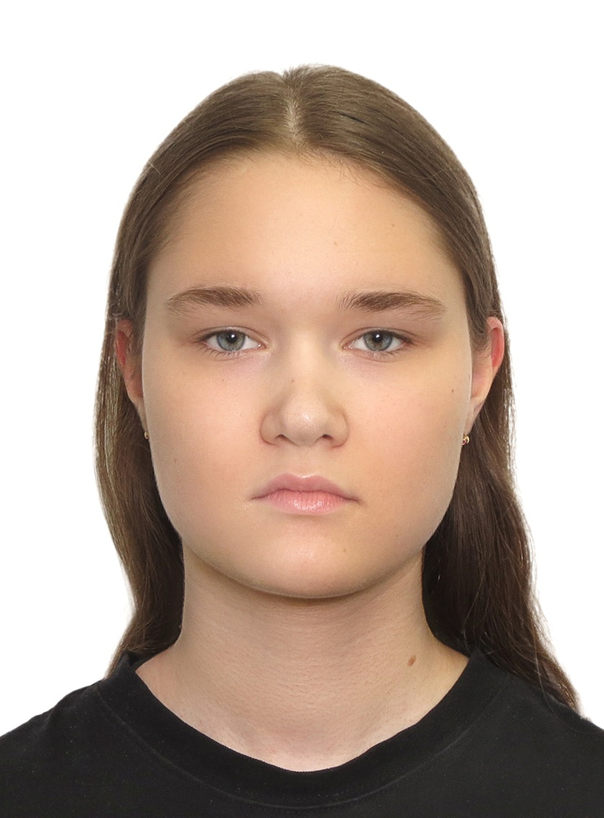

# Вводная часть

## Цель работы

Получение практических навыков работы в консоли с атрибутами файлов для групп пользователей.

## Задание

Добавить пользователей guest и guest2, задать пароли, добавить guest2 в группу guest, войти в систему от двух пользователей на разных консолях, определить директории, уточнить имена пользователей, группы и групповое членство, сравнить вывод команд groups, id -Gn и id -G с содержимым /etc/group, выполнить регистрацию guest2 в группе guest командой newgrp, изменить права директории /home/guest для группы, снять атрибуты с dir1, заполнить таблицы 3.1, 3.2, 3.3.

## Теоретическое введение

Дискреционное управление доступом в ОС Linux обеспечивает возможность управления доступом к данным самими пользователями операционной системы, также оно применяется к каждому субъекту (пользователю) и сущности (файлу, каталогу).

# Выполнение лабораторной работы

## Добавление пользователей и задание паролей

Сначала добавляю пользователей guest и guest2 и задаю пароли (рис. 1).

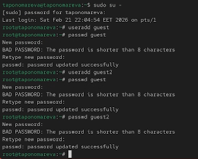

Рисунок 1: Добавление пользователей и задание паролей

## Выполнение заданий

Потом добавляю guest2 в группу guest, вхожу в систему от двух пользователей на разных консолях, определяю директории, уточняю имена пользователей, группы и групповое членство, сравниваю вывод команд groups, id -Gn и id -G с содержимым /etc/group (рис. 2).

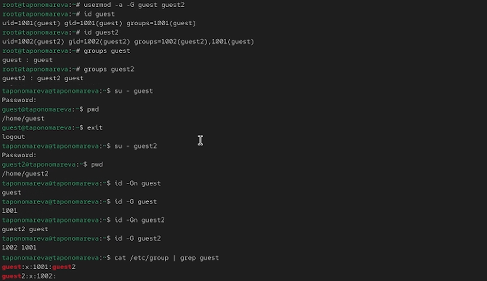

Рисунок 2: Выполнение заданий

## Выполнение заданий

Далее выполняю регистрацию guest2 в группе guest командой newgrp, изменияю права директории /home/guest для группы, снимаю атрибуты с dir1 (рис. 3).

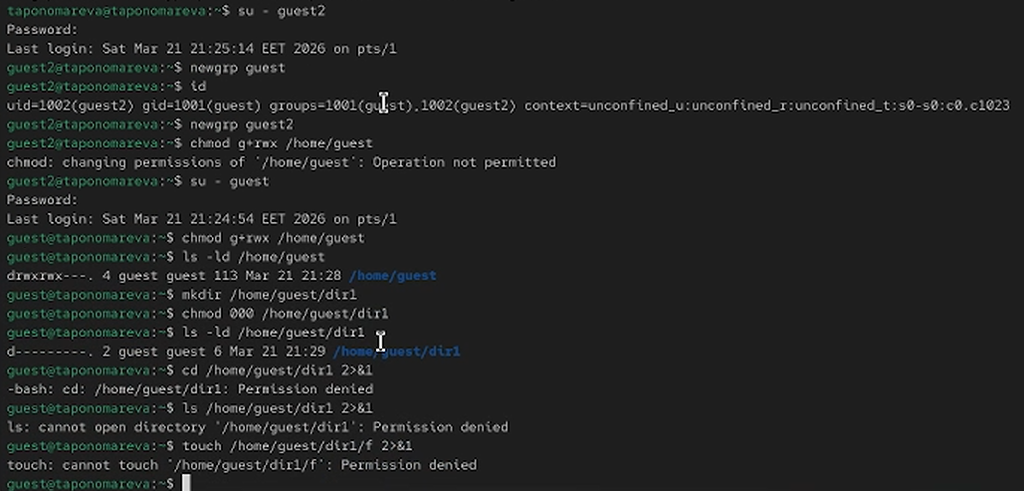

Рисунок 3: Выполнение заданий

Задание 3.1. В таблице табл. 1 можно видеть установленные права и разрешённые действия

Таблица 1: Установленные права и разрешённые действия

[output not shown]

Задание 3.2. В таблице табл. 2 можно видеть, какие операции дают мин права на директорию и на файл

Таблица 2: Минимальные права для совершения операций

[output not shown]

Задание 3.3. В таблице табл. 3 можно видеть сравнение двух таблиц

Таблица 3: Сравнение таблиц из 2 и 3 лабораторных работ

[output not shown]

# Выводы

В ходе проведения лабораторной работы были получены знания по работе в консоли с атрибутами файлов для групп пользователей.

# Список литературы